# Hw2 Task 2

Grace Bianchi

2023-02-12

Overview:

**Data source**: Abrahamson, W.G. 2019. Survival, growth and biomass estimates of two dominant palmetto species of south-central Florida from 1981 - 2017, ongoing at 5-year intervals ver 1. Environmental Data Initiative. https://doi.org/10.6073/pasta/f2f96ec76fbbd4b9db431c79a770c4d5

```r
knitr::opts_chunk$set(echo = TRUE, message = FALSE, warning = FALSE)

library(tidyverse)
library(here)
library(patchwork) # plotting
library(kableExtra) # tables
library(broom)
library(tidymodels) # cross-validation
```

```r
palmetto_data <- read_csv(here("palmetto.csv")) %>%
  mutate(species_name = case_when( # rename species
    species == 1 ~ "Serenoa repens",
     species == 2 ~ "Sabal etonia")) %>%
  mutate(species = as.factor(species), species = fct_drop(species)) # set species column as factor, not numeric
```

## Data Exploration and Visualization

Exploring the differences in height, canopy length, canopy width, and green leaves for the two species; *Serenoa repens* and *Sabal etonia*.

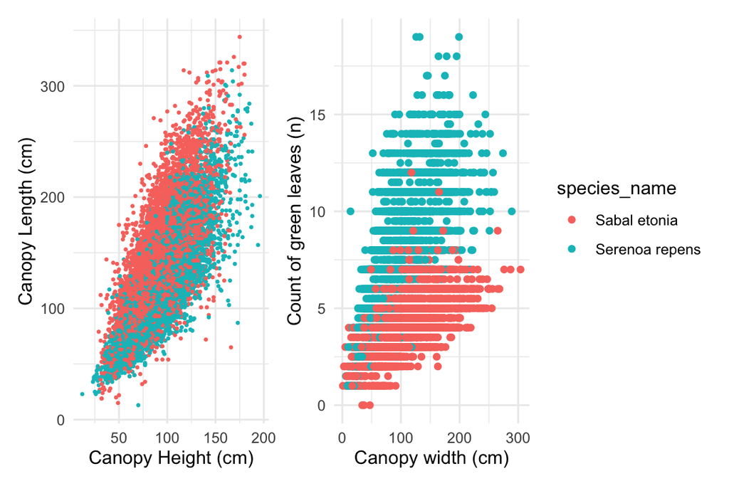

```r
p1 <- ggplot(data = palmetto_data, aes(x = height, y = length)) +
  geom_point(aes(color = species_name), size = .5) +
  labs(x = "Canopy Height (cm)",
       y = "Canopy Length (cm)") +
  theme_minimal() +
  theme(legend.position = "none")

p2<- ggplot(data = palmetto_data, aes(x = width, y = green_lvs)) +
  geom_point(aes(color = species_name)) +
  labs(x = "Canopy width (cm)",
       y = "Count of green leaves (n)") +
  theme_minimal()

p1 + p2
```

### Binary Logistic Regression

Two models are compared and a binary logistic regression is used to determine the probability of a plant being either *Serenoa repens* or *Sabal etonia*. A ten-fold cross validation is used to compare the two models.

#### Model 1: plant height, canopy length and width, and number of green leaves predictor variables

```r
f1 <- species ~ height + length + width + green_lvs

blr_mdl1 <- glm(formula = f1, data = palmetto_data, family = "binomial")

blr_mdl1_tidy <- tidy(blr_mdl1)

blr_mdl1_tidy %>%
  kable(caption = "Table 1. Model 1 Predictor Variable Coefficients", digits = 5,
        col.names= c("Variable", "Coefficient", "Standard Error", "Statistic", "P-value"))  %>%
  kable_classic() %>%
  kable_styling(full_width =  FALSE)
```

Table 1. Model 1 Predictor Variable Coefficients

| Variable | Coefficient | Standard Error | Statistic | P-value |
| --- | --- | --- | --- | --- |
| (Intercept) | 3.22669 | 0.14207 | 22.71180 | 0 |
| height | -0.02922 | 0.00231 | -12.66984 | 0 |
| length | 0.04582 | 0.00187 | 24.55600 | 0 |
| width | 0.03944 | 0.00210 | 18.78227 | 0 |
| green_lvs | -1.90847 | 0.03886 | -49.10728 | 0 |

- The coefficient for height indicates that on average we expect the log odds of a plant being a Sabal etonia decreases by -0.029 for each 1 cm increase in plant height
- The coefficient for canopy length indicates that on average we expect the log odds of a plant being a Sabal etonia increases by 0.046 for each 1 cm increase in canopy length (this coefficient is significant)
- The coefficient for canopy width indicates that, on average, we expect the log odds of a plant being a Sabal etonia increases by 0.039 for each 1 cm increase in canopy width (this coefficient is significant)

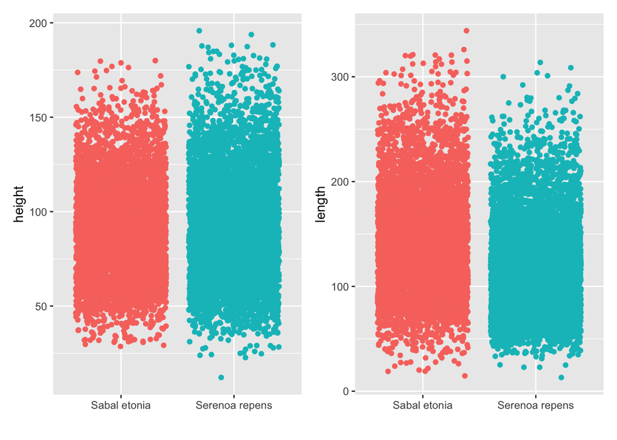

```r
explore_p1 <- ggplot(data = palmetto_data, aes(x = species_name, y = height)) +
  geom_jitter(aes(color = species_name)) +
  theme(legend.position = "none") +
  labs(x = "")

## Species 2 (Sabel estonia) has a distribution of height that is silently lower than species 1 height distribution

explore_p2 <- ggplot(data = palmetto_data, aes(x = species_name, y = length)) +
  geom_jitter(aes(color = species_name)) +
  theme(legend.position = "none") +
  labs(x = "")

## Species 2 (Sabel estonia) has a distribution of height that is silently lower than species 1 length distribution

explore_p1 + explore_p2
```

Figure 2. These exploratory plots show the *Sabel estonia* observations have a lower height and greater length than the *Serenoa repens*, which supports the variable coefficients provided.

#### Model 2: plant height, canopy width and green leaves predictor variables

```r
f2 <- species ~ height + width + green_lvs

blr_mdl2 <- glm(f2, data = palmetto_data, family = "binomial")

blr_mdl2_tidy <- tidy(blr_mdl2)

blr_mdl2_tidy %>%
  kable(caption = 'Table 2. Model 2 Predictor Variable Coefficients', digits = 5,
        col.names= c("Variable", "Coefficient", "Standard Error", "Statistic", "P-value")) %>%
  kable_classic() %>%
  kable_styling(full_width =  FALSE)
```

Table 2. Model 2 Predictor Variable Coefficients

| Variable | Coefficient | Standard Error | Statistic | P-value |
| --- | --- | --- | --- | --- |
| (Intercept) | 3.76772 | 0.13531 | 27.84437 | 0.00000 |
| height | -0.00295 | 0.00188 | -1.56843 | 0.11678 |
| width | 0.06902 | 0.00179 | 38.66063 | 0.00000 |
| green_lvs | -1.88481 | 0.03613 | -52.17220 | 0.00000 |

### Ten-fold cross validation

```r
set.seed(444) ### set seed for reproducibility! here to set the folds

n_folds <- vfold_cv(palmetto_data, v = 10, repeats = 10)

### use a workflow that bundles the logistic model and a formula
blr_model <- logistic_reg() %>%
   set_engine('glm')

## model 1
blr_tidy_wf1 <- workflow() %>%
  add_model(blr_model) %>%
  add_formula(f1)

blr_tidy_cv_f1 <- blr_tidy_wf1 %>%
  fit_resamples(n_folds)

### use functions from the tune package to extract metrics
cv_blr1_metrics <- collect_metrics(blr_tidy_cv_f1)

# run for model 2
blr_tidy_wf2 <- workflow() %>%
  add_model(blr_model) %>%
  add_formula(f2)

blr_tidy_cv_f2 <- blr_tidy_wf2 %>%
  fit_resamples(n_folds)

### use functions from the tune package to extract metrics
cv_blr2_metrics <- collect_metrics(blr_tidy_cv_f2)
```

```r
## cross validation tables
cv_blr1_metrics %>% kable(caption = "Table 3. Cross validation Metrics for Model 1",
                          col.names = c("Metric", "Estimator", "Mean", "n", "Standard Error", "configuration"),
                          digits = 5,
                          align = 'clc') %>%
  remove_column(.,6) %>%
  kable_classic() %>%
  kable_styling(full_width =  FALSE, position = "float_left")
```

Table 3. Cross validation Metrics for Model 1

| Metric | Estimator | Mean | n | Standard Error |
| --- | --- | --- | --- | --- |
| accuracy | binary | 0.91677 | 100 | 0.00075 |
| roc_auc | binary | 0.97254 | 100 | 0.00033 |

```r
cv_blr2_metrics %>% kable(caption = "Table 4. Cross validation Metrics for Model 2",
                          col.names = c("Metric", "Estimator", "Mean", "n", "Standard Error", "configuration"),
                          digits = 5,
                          align = 'clc') %>%
  remove_column(.,6) %>%
  kable_classic() %>%
  kable_styling(full_width =  FALSE, position = "right")
```

Table 4. Cross validation Metrics for Model 2

| Metric | Estimator | Mean | n | Standard Error |
| --- | --- | --- | --- | --- |
| accuracy | binary | 0.89886 | 100 | 0.00076 |
| roc_auc | binary | 0.96351 | 100 | 0.00038 |

After comparing the results of the cross validation, Model 1 (mean = 0.9168) had a greater accuracy when compared to Model 2 (mean = 0.8989). Thus, we can conclude Model 1 is the better model when predicting palmetto species.

A section that evaluates how successfully this model would “classify” a plant as the correct species, using a 50% cutoff (e.g. if the probability is >=50% that it is species A, then it would be classified as species A).

### Model 1 Species Predictions

```r
# converts the log odds to the probability of being Sabal etonia for each observation.
blr1_fitted <- blr_mdl1 %>%
  broom::augment(type.predict = "response")


blr1_acc <- blr1_fitted %>%
  # predict species using 50% threshold
  mutate(spp_prediction = ifelse(.fitted > 0.5, "2", "1")) %>%
 # add score for correct predictions
  mutate(spp_accuracy = ifelse(spp_prediction == species, "yes", "no")) %>%
  group_by(species) %>%
  summarize(n_correct = sum(spp_accuracy == "yes"),
            n_incorrect = sum(spp_accuracy == "no"),
            pct_correct = (n_correct/(n_correct + n_incorrect))*100) %>%
  mutate(pct_correct = round(pct_correct, digits = 1))
```

```r
# make table with number of incorrect and correct predictions
blr1_acc %>%
  kable(caption = "Table 4. Plant Classification using Model 1",
        col.names = c("Species", "Correctly classified (n)", "Incorrectly classified (n)", "% Correctly classified")) %>%
  kable_classic() %>%
  kable_styling(full_width = FALSE)
```

Table 4. Plant Classification using Model 1

| Species | Correctly classified (n) | Incorrectly classified (n) | % Correctly classified |
| --- | --- | --- | --- |
| 1 | 5548 | 564 | 90.8 |
| 2 | 5701 | 454 | 92.6 |

Model 1 was used to classify each plant, in which it correctly identified 91.7 % or 11249 plants out of 12267. In conclusion, Model 1 was the better predictor for species classification using plant height, canopy width, canopy length, and number of green leaves as predictor variables.